# Linear Models with R - Exercises

Rachel Greenlee

8/28/2021

#Linear Models w/ R Chapter 1

## Exercise 1.1

The dataset teengamb concerns a study of teenage gambling in Britain. Make a numerical and graphical summary of the data, commenting on any features that you find interesting. Limit the output you present to a quantity that a busy reader would find sufficient to get a basic understanding of the data.

```r
head(teengamb)
```

```
##   sex status income verbal gamble
## 1   1     51   2.00      8    0.0
## 2   1     28   2.50      8    0.0
## 3   1     37   2.00      6    0.0
## 4   1     28   7.00      4    7.3
## 5   1     65   2.00      8   19.6
## 6   1     61   3.47      6    0.1
```

```r
summary(teengamb)
```

```
##       sex             status          income           verbal
##  Min.   :0.0000   Min.   :18.00   Min.   : 0.600   Min.   : 1.00
##  1st Qu.:0.0000   1st Qu.:28.00   1st Qu.: 2.000   1st Qu.: 6.00
##  Median :0.0000   Median :43.00   Median : 3.250   Median : 7.00
##  Mean   :0.4043   Mean   :45.23   Mean   : 4.642   Mean   : 6.66
##  3rd Qu.:1.0000   3rd Qu.:61.50   3rd Qu.: 6.210   3rd Qu.: 8.00
##  Max.   :1.0000   Max.   :75.00   Max.   :15.000   Max.   :10.00
##      gamble
##  Min.   :  0.0
##  1st Qu.:  1.1
##  Median :  6.0
##  Mean   : 19.3
##  3rd Qu.: 19.4
##  Max.   :156.0
```

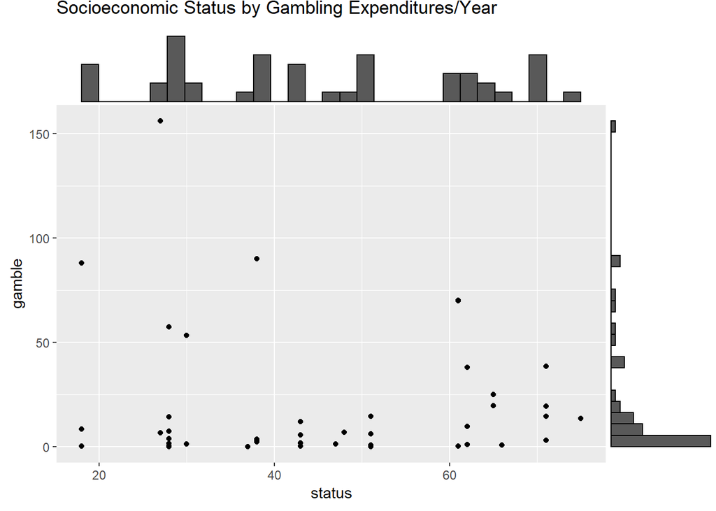

```r
p1 <- ggplot(teengamb, aes(x = status, y = gamble)) +
  geom_point() +
  labs(title = "Socioeconomic Status by Gambling Expenditures/Year")

ggExtra::ggMarginal(p1, type = "histogram")
```

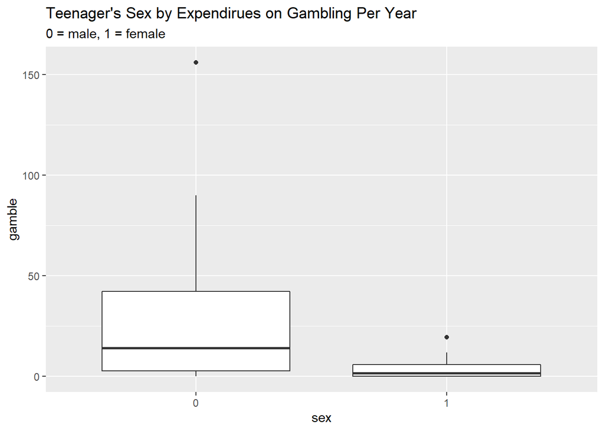

```r
teengamb$sex <- as.factor(teengamb$sex)

ggplot(teengamb, aes(x = sex, y = gamble)) +
  geom_boxplot() +
  labs(title = "Teenager's Sex by Expendirues on Gambling Per Year",
       subtitle = "0 = male, 1 = female")
```

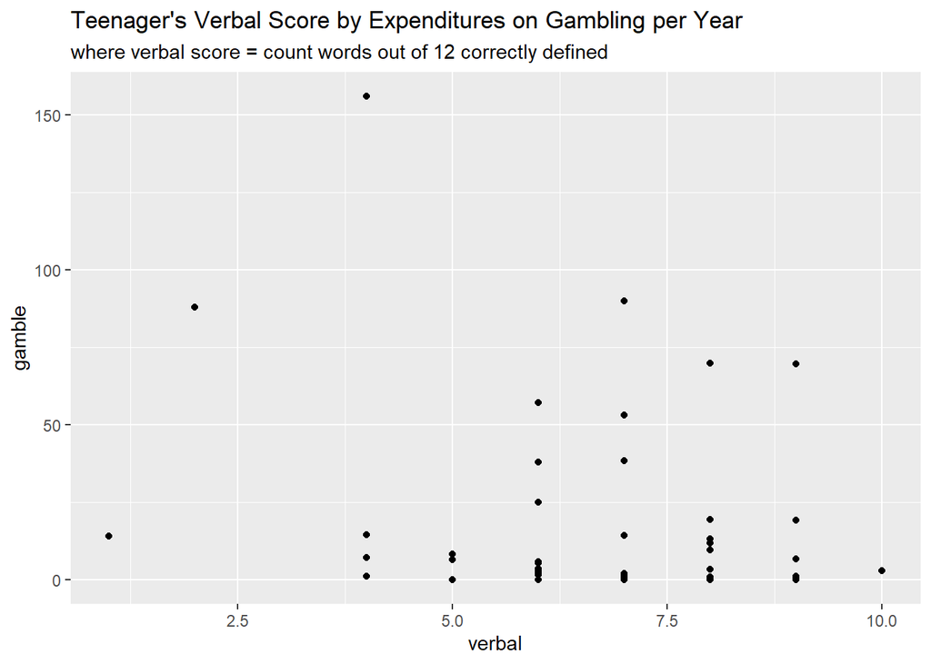

```r
ggplot(teengamb, aes(x = verbal, y = gamble)) +
  geom_point() +
  labs(title = "Teenager's Verbal Score by Expenditures on Gambling per Year",
       subtitle = "where verbal score = count words out of 12 correctly defined")
```

## Exercise 1.3

The dataset prostate is from a study on 97 men with prostate cancer who were due to receive a radical prostatectomy. Make a numerical and graphical summary of the data as in the first question.

```r
head(prostate)
```

```
##       lcavol lweight age      lbph svi      lcp gleason pgg45     lpsa
## 1 -0.5798185  2.7695  50 -1.386294   0 -1.38629       6     0 -0.43078
## 2 -0.9942523  3.3196  58 -1.386294   0 -1.38629       6     0 -0.16252
## 3 -0.5108256  2.6912  74 -1.386294   0 -1.38629       7    20 -0.16252
## 4 -1.2039728  3.2828  58 -1.386294   0 -1.38629       6     0 -0.16252
## 5  0.7514161  3.4324  62 -1.386294   0 -1.38629       6     0  0.37156
## 6 -1.0498221  3.2288  50 -1.386294   0 -1.38629       6     0  0.76547
```

```r
summary(prostate)
```

```
##      lcavol           lweight           age             lbph
##  Min.   :-1.3471   Min.   :2.375   Min.   :41.00   Min.   :-1.3863
##  1st Qu.: 0.5128   1st Qu.:3.376   1st Qu.:60.00   1st Qu.:-1.3863
##  Median : 1.4469   Median :3.623   Median :65.00   Median : 0.3001
##  Mean   : 1.3500   Mean   :3.653   Mean   :63.87   Mean   : 0.1004
##  3rd Qu.: 2.1270   3rd Qu.:3.878   3rd Qu.:68.00   3rd Qu.: 1.5581
##  Max.   : 3.8210   Max.   :6.108   Max.   :79.00   Max.   : 2.3263
##       svi              lcp             gleason          pgg45
##  Min.   :0.0000   Min.   :-1.3863   Min.   :6.000   Min.   :  0.00
##  1st Qu.:0.0000   1st Qu.:-1.3863   1st Qu.:6.000   1st Qu.:  0.00
##  Median :0.0000   Median :-0.7985   Median :7.000   Median : 15.00
##  Mean   :0.2165   Mean   :-0.1794   Mean   :6.753   Mean   : 24.38
##  3rd Qu.:0.0000   3rd Qu.: 1.1786   3rd Qu.:7.000   3rd Qu.: 40.00
##  Max.   :1.0000   Max.   : 2.9042   Max.   :9.000   Max.   :100.00
##       lpsa
##  Min.   :-0.4308
##  1st Qu.: 1.7317
##  Median : 2.5915
##  Mean   : 2.4784
##  3rd Qu.: 3.0564
##  Max.   : 5.5829
```

## Exercise 1.4

The dataset sat comes from a study entitled “Getting What You Pay For: The Debate Over Equity in Public School Expenditures.” Make a numerical and graphical summary of the data as in the first question

```r
head(sat)
```

```
##            expend ratio salary takers verbal math total
## Alabama     4.405  17.2 31.144      8    491  538  1029
## Alaska      8.963  17.6 47.951     47    445  489   934
## Arizona     4.778  19.3 32.175     27    448  496   944
## Arkansas    4.459  17.1 28.934      6    482  523  1005
## California  4.992  24.0 41.078     45    417  485   902
## Colorado    5.443  18.4 34.571     29    462  518   980
```

```r
summary(sat)
```

```
##      expend          ratio           salary          takers
##  Min.   :3.656   Min.   :13.80   Min.   :25.99   Min.   : 4.00
##  1st Qu.:4.882   1st Qu.:15.22   1st Qu.:30.98   1st Qu.: 9.00
##  Median :5.768   Median :16.60   Median :33.29   Median :28.00
##  Mean   :5.905   Mean   :16.86   Mean   :34.83   Mean   :35.24
##  3rd Qu.:6.434   3rd Qu.:17.57   3rd Qu.:38.55   3rd Qu.:63.00
##  Max.   :9.774   Max.   :24.30   Max.   :50.05   Max.   :81.00
##      verbal           math           total
##  Min.   :401.0   Min.   :443.0   Min.   : 844.0
##  1st Qu.:427.2   1st Qu.:474.8   1st Qu.: 897.2
##  Median :448.0   Median :497.5   Median : 945.5
##  Mean   :457.1   Mean   :508.8   Mean   : 965.9
##  3rd Qu.:490.2   3rd Qu.:539.5   3rd Qu.:1032.0
##  Max.   :516.0   Max.   :592.0   Max.   :1107.0
```

## Exercise 1.5

The dataset divusa contains data on divorces in the United States from 1920 to 1996. Make a numerical and graphical summary of the data as in the first question.

```r
head(divusa)
```

```
##   year divorce unemployed femlab marriage birth military
## 1 1920     8.0        5.2  22.70     92.0 117.9   3.2247
## 2 1921     7.2       11.7  22.79     83.0 119.8   3.5614
## 3 1922     6.6        6.7  22.88     79.7 111.2   2.4553
## 4 1923     7.1        2.4  22.97     85.2 110.5   2.2065
## 5 1924     7.2        5.0  23.06     80.3 110.9   2.2889
## 6 1925     7.2        3.2  23.15     79.2 106.6   2.1735
```

```r
summary(divusa)
```

```
##       year         divorce        unemployed         femlab
##  Min.   :1920   Min.   : 6.10   Min.   : 1.200   Min.   :22.70
##  1st Qu.:1939   1st Qu.: 8.70   1st Qu.: 4.200   1st Qu.:27.47
##  Median :1958   Median :10.60   Median : 5.600   Median :37.10
##  Mean   :1958   Mean   :13.27   Mean   : 7.173   Mean   :38.58
##  3rd Qu.:1977   3rd Qu.:20.30   3rd Qu.: 7.500   3rd Qu.:47.80
##  Max.   :1996   Max.   :22.80   Max.   :24.900   Max.   :59.30
##     marriage          birth           military
##  Min.   : 49.70   Min.   : 65.30   Min.   : 1.940
##  1st Qu.: 61.90   1st Qu.: 68.90   1st Qu.: 3.469
##  Median : 74.10   Median : 85.90   Median : 9.102
##  Mean   : 72.97   Mean   : 88.89   Mean   :12.365
##  3rd Qu.: 80.00   3rd Qu.:107.30   3rd Qu.:14.266
##  Max.   :118.10   Max.   :122.90   Max.   :86.641
```

#Linear Models w/ R Chapter 2

## Exercise 2.4

The dataset prostate comes from a study on 97 men with prostate cancer who were due to receive a radical prostatectomy. Fit a model with lpsa as the response and lcavol as the predictor. Record the residual standard error and the R2. Now add lweight, svi, lbph, age, lcp, pgg45 and gleason to the model one at a time. For each model record the residual standard error and the R2. Plot the trends in these two statistics.

```r
# view data summary and pull up help file with variable definitions
summary(prostate)
```

```
##      lcavol           lweight           age             lbph
##  Min.   :-1.3471   Min.   :2.375   Min.   :41.00   Min.   :-1.3863
##  1st Qu.: 0.5128   1st Qu.:3.376   1st Qu.:60.00   1st Qu.:-1.3863
##  Median : 1.4469   Median :3.623   Median :65.00   Median : 0.3001
##  Mean   : 1.3500   Mean   :3.653   Mean   :63.87   Mean   : 0.1004
##  3rd Qu.: 2.1270   3rd Qu.:3.878   3rd Qu.:68.00   3rd Qu.: 1.5581
##  Max.   : 3.8210   Max.   :6.108   Max.   :79.00   Max.   : 2.3263
##       svi              lcp             gleason          pgg45
##  Min.   :0.0000   Min.   :-1.3863   Min.   :6.000   Min.   :  0.00
##  1st Qu.:0.0000   1st Qu.:-1.3863   1st Qu.:6.000   1st Qu.:  0.00
##  Median :0.0000   Median :-0.7985   Median :7.000   Median : 15.00
##  Mean   :0.2165   Mean   :-0.1794   Mean   :6.753   Mean   : 24.38
##  3rd Qu.:0.0000   3rd Qu.: 1.1786   3rd Qu.:7.000   3rd Qu.: 40.00
##  Max.   :1.0000   Max.   : 2.9042   Max.   :9.000   Max.   :100.00
##       lpsa
##  Min.   :-0.4308
##  1st Qu.: 1.7317
##  Median : 2.5915
##  Mean   : 2.4784
##  3rd Qu.: 3.0564
##  Max.   : 5.5829
```

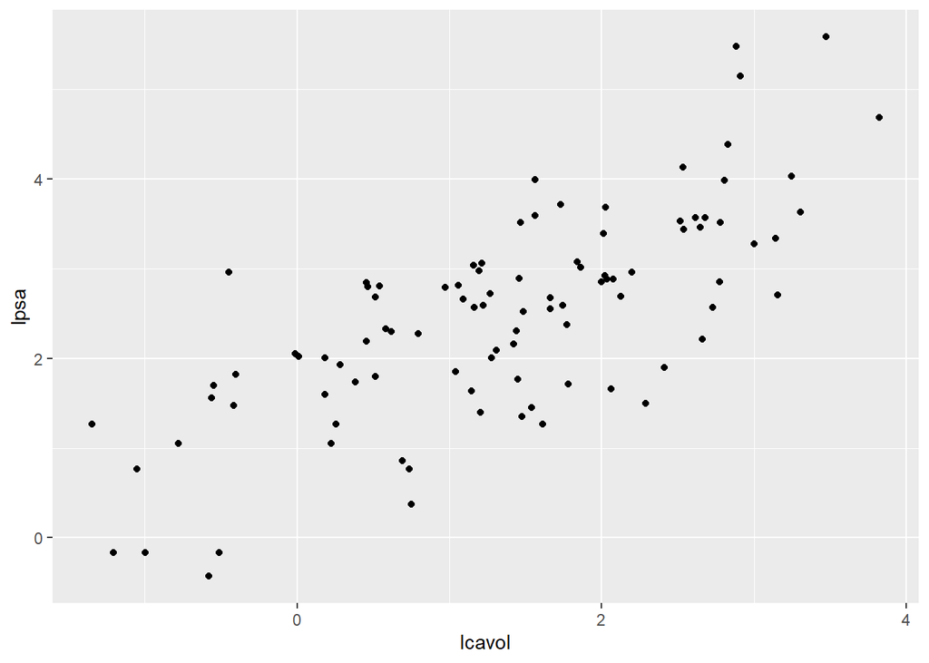

```r
# always plot variables before running regression
ggplot(prostate, aes(x = lcavol, y = lpsa)) +
  geom_point()
```

```r
# run base regression

lm1 <- lm(lpsa ~
            lcavol, data = prostate)
#summary(lm1)

df24 <- data.frame("adjR" = summary(lm1)$adj.r.squared, "residSE" = summary(lm1)$sigma)

# adding one variable at a time & storing adjR and residSE
lm2 <- lm(lpsa ~
            lcavol +
            lweight, data = prostate)
df24 <- rbind(df24, list(summary(lm2)$adj.r.squared, summary(lm2)$sigma))


lm3 <- lm(lpsa ~
            lcavol +
            lweight +
            svi, data = prostate)
df24 <- rbind(df24, list(summary(lm3)$adj.r.squared, summary(lm3)$sigma))


lm4 <- lm(lpsa ~
            lcavol +
            lweight +
            svi +
            lbph, data = prostate)
df24 <- rbind(df24, list(summary(lm4)$adj.r.squared, summary(lm4)$sigma))


lm5 <- lm(lpsa ~
            lcavol +
            lweight +
            svi +
            lbph +
            age, data = prostate)
df24 <- rbind(df24, list(summary(lm5)$adj.r.squared, summary(lm5)$sigma))


lm6 <- lm(lpsa ~
            lcavol +
            lweight +
            svi +
            lbph +
            age +
            lcp, data = prostate)
df24 <- rbind(df24, list(summary(lm6)$adj.r.squared, summary(lm6)$sigma))


lm7 <- lm(lpsa ~
            lcavol +
            lweight +
            svi +
            lbph +
            age +
            lcp +
            pgg45, data = prostate)
df24 <- rbind(df24, list(summary(lm7)$adj.r.squared, summary(lm7)$sigma))

lm8 <- lm(lpsa ~
            lcavol +
            lweight +
            svi +
            lbph +
            age +
            lcp +
            pgg45 +
            gleason, data = prostate)
df24 <- rbind(df24, list(summary(lm8)$adj.r.squared, summary(lm8)$sigma))
```

### It appears the adjusted R-squared and the residual standard error have a perfect linear relationship.

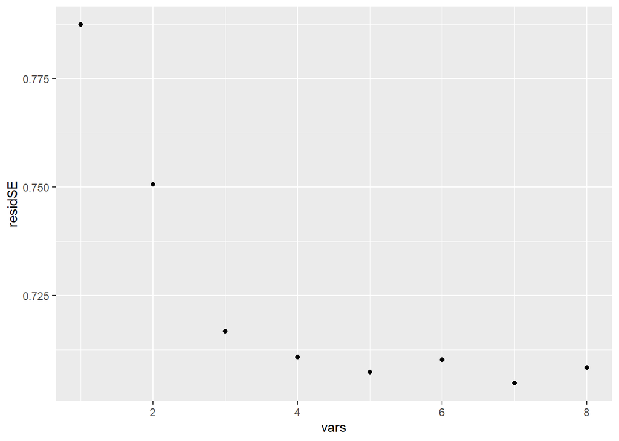

```r
# plotting the stored adjusted R-squared and residual standard error from each
# model

df24$vars <- 1:nrow(df24)

ggplot(df24, aes(x = vars, y = residSE)) +
  geom_point()
```

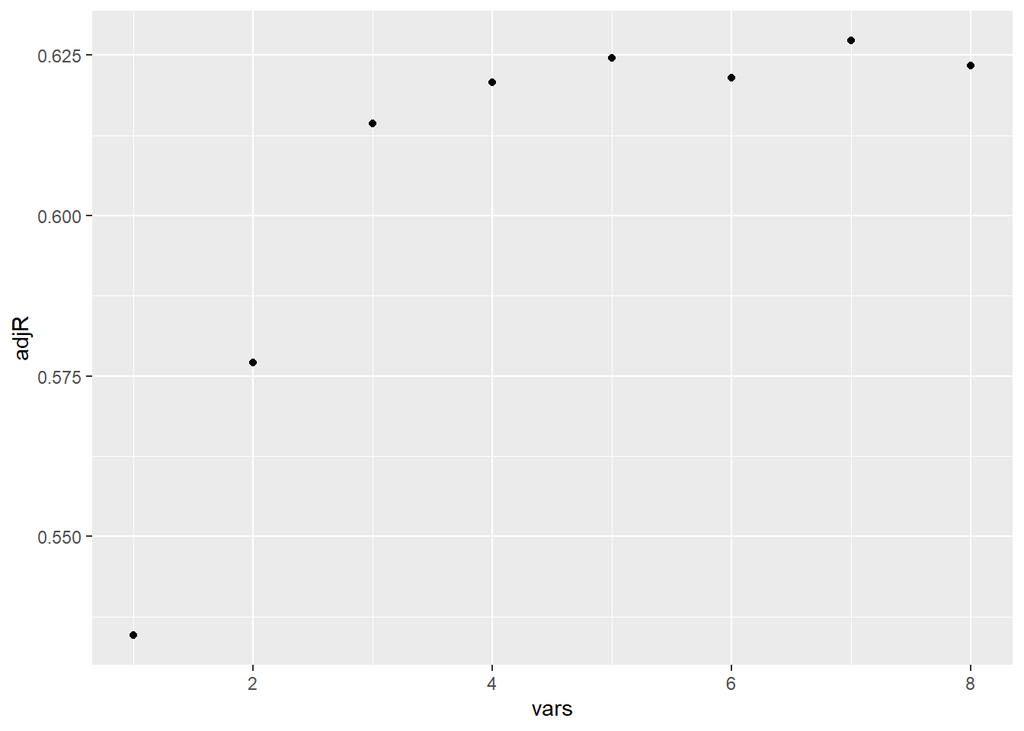

```r
ggplot(df24, aes(x = vars, y = adjR)) +
  geom_point()
```

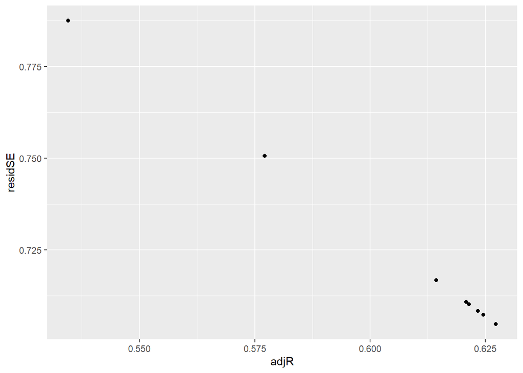

```r
ggplot(df24, aes(x = adjR, y = residSE)) +
  geom_point()
```

## Exercise 2.5

Using the prostate data, plot lpsa against lcavol. Fit the regressions of lpsa on lcavol and lcavol on lpsa. Display both regression lines on the plot. At what point do the two lines intersect?

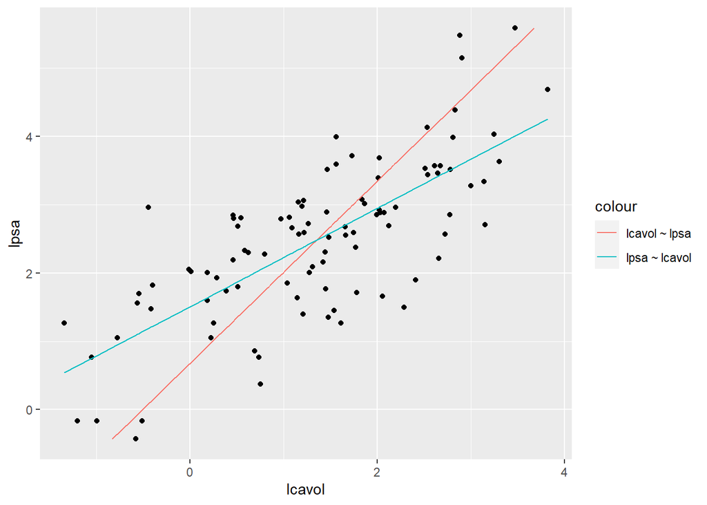

```r
lmA <- lm(lcavol ~ lpsa, data = prostate)
lmB <- lm(lpsa ~ lcavol, data = prostate)

ggplot(prostate, aes(lcavol, lpsa)) +
  geom_point() +
  geom_line(aes(x = predict(lmA), color = "lcavol ~ lpsa")) +
  geom_line(aes(y = predict(lmB), color = "lpsa ~ lcavol"))
```

#Linear Models w/ R Chapter 3 ## Exercise 3.4

4. Using the sat data:
1. Fit a model with total sat score as the response and expend, ratio and salary as predictors. Test the hypothesis that βsalary = 0. Test the hypothesis that βsalary = βratio = βexpend = 0. Do any of these predictors have an effect on the response?

```r
head(sat)
```

```
##            expend ratio salary takers verbal math total
## Alabama     4.405  17.2 31.144      8    491  538  1029
## Alaska      8.963  17.6 47.951     47    445  489   934
## Arizona     4.778  19.3 32.175     27    448  496   944
## Arkansas    4.459  17.1 28.934      6    482  523  1005
## California  4.992  24.0 41.078     45    417  485   902
## Colorado    5.443  18.4 34.571     29    462  518   980
```

```r
# model with 3 predictors
sat_lm1 <- lm(total ~ expend + ratio + salary, data = sat)
summary(sat_lm1)
```

```
##
## Call:
## lm(formula = total ~ expend + ratio + salary, data = sat)
##
## Residuals:
##      Min       1Q   Median       3Q      Max
## -140.911  -46.740   -7.535   47.966  123.329
##
## Coefficients:
##             Estimate Std. Error t value Pr(>|t|)
## (Intercept) 1069.234    110.925   9.639 1.29e-12 ***
## expend        16.469     22.050   0.747   0.4589
## ratio          6.330      6.542   0.968   0.3383
## salary        -8.823      4.697  -1.878   0.0667 .
## ---
## Signif. codes:  0 '***' 0.001 '**' 0.01 '*' 0.05 '.' 0.1 ' ' 1
##
## Residual standard error: 68.65 on 46 degrees of freedom
## Multiple R-squared:  0.2096, Adjusted R-squared:  0.1581
## F-statistic: 4.066 on 3 and 46 DF,  p-value: 0.01209
```

```r
# test null hypothesis that Beta_salary = 0
# meaning that the salary alone doesn't have any slope/affect on total avg score
sat_lm2 <- lm(total ~ salary, data = sat)
summary(sat_lm2)
```

```
##
## Call:
## lm(formula = total ~ salary, data = sat)
##
## Residuals:
##      Min       1Q   Median       3Q      Max
## -147.125  -45.354    4.073   42.193  125.279
##
## Coefficients:
##             Estimate Std. Error t value Pr(>|t|)
## (Intercept) 1158.859     57.659  20.098  < 2e-16 ***
## salary        -5.540      1.632  -3.394  0.00139 **
## ---
## Signif. codes:  0 '***' 0.001 '**' 0.01 '*' 0.05 '.' 0.1 ' ' 1
##
## Residual standard error: 67.89 on 48 degrees of freedom
## Multiple R-squared:  0.1935, Adjusted R-squared:  0.1767
## F-statistic: 11.52 on 1 and 48 DF,  p-value: 0.001391
```

The null hypothesis that βsalary = βratio = βexpend = 0 is rejected due to the small p-value of 0.0121.

```r
# create model where slope = 1 (aka no variables predicting)
sat_nullmod <- lm(total ~ 1, sat)

# compare null to our model created above
anova(sat_nullmod, sat_lm1)
```

```
## Analysis of Variance Table
##
## Model 1: total ~ 1
## Model 2: total ~ expend + ratio + salary
##   Res.Df    RSS Df Sum of Sq      F  Pr(>F)
## 1     49 274308
## 2     46 216812  3     57496 4.0662 0.01209 *
## ---
## Signif. codes:  0 '***' 0.001 '**' 0.01 '*' 0.05 '.' 0.1 ' ' 1
```

2. Now add takers to the model. Test the hypothesis that βtakers = 0. Compare this model to the previous one using an F-test. Demonstrate that the F-test and t-test here are equivalent.

```r
# model with 4 predictors
sat_lm3 <- lm(total ~ expend + ratio + salary + takers, data = sat)
summary(sat_lm3)
```

```
##
## Call:
## lm(formula = total ~ expend + ratio + salary + takers, data = sat)
##
## Residuals:
##     Min      1Q  Median      3Q     Max
## -90.531 -20.855  -1.746  15.979  66.571
##
## Coefficients:
##              Estimate Std. Error t value Pr(>|t|)
## (Intercept) 1045.9715    52.8698  19.784  < 2e-16 ***
## expend         4.4626    10.5465   0.423    0.674
## ratio         -3.6242     3.2154  -1.127    0.266
## salary         1.6379     2.3872   0.686    0.496
## takers        -2.9045     0.2313 -12.559 2.61e-16 ***
## ---
## Signif. codes:  0 '***' 0.001 '**' 0.01 '*' 0.05 '.' 0.1 ' ' 1
##
## Residual standard error: 32.7 on 45 degrees of freedom
## Multiple R-squared:  0.8246, Adjusted R-squared:  0.809
## F-statistic: 52.88 on 4 and 45 DF,  p-value: < 2.2e-16
```

The hypothesis that βtakers = 0 is rejected due to a low p-value of nearly zero.

```r
# test null hypothesis that Beta_takers = 0
# meaning that the takers alone doesn't have any slope/affect on total avg score
sat_lm4 <- lm(total ~ takers, data = sat)
summary(sat_lm4)
```

```
##
## Call:
## lm(formula = total ~ takers, data = sat)
##
## Residuals:
##     Min      1Q  Median      3Q     Max
## -79.158 -27.364   3.308  19.876  66.080
##
## Coefficients:
##              Estimate Std. Error t value Pr(>|t|)
## (Intercept) 1053.3204     8.2112  128.28   <2e-16 ***
## takers        -2.4801     0.1862  -13.32   <2e-16 ***
## ---
## Signif. codes:  0 '***' 0.001 '**' 0.01 '*' 0.05 '.' 0.1 ' ' 1
##
## Residual standard error: 34.89 on 48 degrees of freedom
## Multiple R-squared:  0.787,  Adjusted R-squared:  0.7825
## F-statistic: 177.3 on 1 and 48 DF,  p-value: < 2.2e-16
```

The test shows that the model with the addition of ‘takers’ is justifiable due to the small p-value.

```r
anova(sat_lm1, sat_lm3)
```

```
## Analysis of Variance Table
##
## Model 1: total ~ expend + ratio + salary
## Model 2: total ~ expend + ratio + salary + takers
##   Res.Df    RSS Df Sum of Sq      F    Pr(>F)
## 1     46 216812
## 2     45  48124  1    168688 157.74 2.607e-16 ***
## ---
## Signif. codes:  0 '***' 0.001 '**' 0.01 '*' 0.05 '.' 0.1 ' ' 1
```

#Linear Models w/ R Chapter 4 ## Exercise 4.5

5. For the fat data used in this chapter, a smaller model using only age, weight, height and abdom was proposed on the grounds that these predictors are either known by the individual or easily measured.

```r
fat_lm0 <- lm(brozek ~ age + weight + height + neck + chest + abdom + hip +
                thigh + knee + ankle + biceps + forearm + wrist, data=fat)
fat_lm1 <- lm(brozek ~ age + weight + height + abdom, data = fat)
```

1. Compare this model to the full thirteen-predictor model used earlier in the chapter. Is it justifiable to use the smaller model?

Since the p-value is small the null hypothesis is rejected. Removing all of the predictors is not justifiable.

We were essentially testing a H0: β’s of the removed predictors = 0. They do not equal zero, so we can’t remove them (may be better to test one at a time).

```r
anova(fat_lm1, fat_lm0)
```

```
## Analysis of Variance Table
##
## Model 1: brozek ~ age + weight + height + abdom
## Model 2: brozek ~ age + weight + height + neck + chest + abdom + hip +
##     thigh + knee + ankle + biceps + forearm + wrist
##   Res.Df    RSS Df Sum of Sq      F   Pr(>F)
## 1    247 4205.0
## 2    238 3785.1  9     419.9 2.9336 0.002558 **
## ---
## Signif. codes:  0 '***' 0.001 '**' 0.01 '*' 0.05 '.' 0.1 ' ' 1
```

2. Compute a 95% prediction interval for median predictor values and compare to the results to the interval for the full model. Do the intervals differ by a practically important amount?

Full model is body fat between 9.62% and 25.37%.

Smaller model is body fat between 9.7% and 25.98%.  
I would argue they do not differ by an practically important amount a user would care about.

```r
# grab model and get median coefficients in format the predict func will like
fat_lm0_matrix <- model.matrix(fat_lm0)
(fat_lm0_medians <- apply(fat_lm0_matrix, 2, median))
```

```
## (Intercept)         age      weight      height        neck       chest
##        1.00       43.00      176.50       70.00       38.00       99.65
##       abdom         hip       thigh        knee       ankle      biceps
##       90.95       99.30       59.00       38.50       22.80       32.05
##     forearm       wrist
##       28.70       18.30
```

```r
predict(fat_lm0, new = data.frame(t(fat_lm0_medians)), interval = "prediction")
```

```
##        fit     lwr      upr
## 1 17.49322 9.61783 25.36861
```

```r
# and again for the smaller model
fat_lm1_matrix <- model.matrix(fat_lm1)
(fat_lm1_medians <- apply(fat_lm1_matrix, 2, median))
```

```
## (Intercept)         age      weight      height       abdom
##        1.00       43.00      176.50       70.00       90.95
```

```r
predict(fat_lm1, new = data.frame(t(fat_lm1_medians)), interval = "prediction")
```

```
##        fit      lwr      upr
## 1 17.84028 9.696631 25.98392
```

3. For the smaller model, examine all the observations from case numbers 25 to
50. Which two observations seem particularly anomalous?

```r
new_df_25_50 <- fat[25:50,c(4,5,6,11)]
predict(fat_lm1, new=data.frame(new_df_25_50), interval="prediction")
```

```
##          fit         lwr      upr
## 25  8.298418  0.08103281 16.51580
## 26  9.903086  1.71322935 18.09294
## 27  9.216292  1.01552526 17.41706
## 28 19.740864 11.48411519 27.99761
## 29  8.747253  0.49903716 16.99547
## 30 13.376012  5.19875861 21.55326
## 31 14.797935  6.62619278 22.96968
## 32 14.065015  5.88455369 22.24548
## 33  8.315872  0.10061987 16.53112
## 34 21.038046 12.84083747 29.23525
## 35 30.623842 22.38906643 38.85862
## 36 36.201628 27.83841989 44.56484
## 37 23.528151 15.36925601 31.68705
## 38 22.473944 14.31151961 30.63637
## 39 45.310482 36.47199166 54.14897
## 40 30.120799 21.92013711 38.32146
## 41 38.663109 30.34468421 46.98153
## 42 30.910811 20.40248479 41.41914
## 43 30.810797 22.61170204 39.00989
## 44 25.164766 16.99699489 33.33254
## 45 11.141535  2.93651578 19.34655
## 46 10.568910  2.38586739 18.75195
## 47  8.125807 -0.07361926 16.32523
## 48 10.999713  2.82955826 19.16987
## 49 16.325612  8.12181572 24.52941
## 50  5.970276 -2.26886915 14.20942
```

4. Recompute the 95% prediction interval for median predictor values after these two anomalous cases have been excluded from the data. Did this make much difference to the outcome?

```r
fat_cleaned <- fat[-c(47, 50),]

fat_lm1_cleaned <- lm(brozek ~ age + weight + height + abdom, data = fat_cleaned)

fat_lm1_cleaned_matrix <- model.matrix(fat_lm1_cleaned)
(fat_lm1_cleaned_medians <- apply(fat_lm1_cleaned_matrix, 2, median))
```

```
## (Intercept)         age      weight      height       abdom
##       1.000      43.000     176.750      70.125      91.050
```

```r
predict(fat_lm1_cleaned, new = data.frame(t(fat_lm1_cleaned_medians)), interval = "prediction")
```

```
##        fit      lwr      upr
## 1 17.87271 9.705645 26.03977
```

#Linear Models w/ R Chapter 5 ## Exercise 5.2

Use the odor dataset with odor as the response and temp as a predictor. Consider all possible models that also include all, some or none of the other two predictors. Report the coefficient for temperature, its standard error, t-statistic and p-value in each case. Discuss what stays the same, what changes and why. Which model is best?

```r
head(odor)
```

```
##   odor temp gas pack
## 1   66   -1  -1    0
## 2   39    1  -1    0
## 3   43   -1   1    0
## 4   49    1   1    0
## 5   58   -1   0   -1
## 6   17    1   0   -1
```

None of the Adjusted R-Squared in the 4 models are all that good, some are even negative. No significant p-values.

```r
odor_lm0 <- lm(odor ~ temp, data = odor)
odor_lm_some <- lm(odor ~ temp + gas, data = odor)
odor_lm_some2 <- lm(odor ~ pack + gas, data = odor)
odor_lm_all <- lm(odor ~ temp + gas + pack, data = odor)

summary(odor_lm0)
```

```
##
## Call:
## lm(formula = odor ~ temp, data = odor)
##
## Residuals:
##    Min     1Q Median     3Q    Max
## -50.20 -39.20  13.93  33.30  49.80
##
## Coefficients:
##             Estimate Std. Error t value Pr(>|t|)
## (Intercept)    15.20      10.19   1.492     0.16
## temp          -12.13      13.95  -0.869     0.40
##
## Residual standard error: 39.45 on 13 degrees of freedom
## Multiple R-squared:  0.05494,    Adjusted R-squared:  -0.01776
## F-statistic: 0.7557 on 1 and 13 DF,  p-value: 0.4004
```

```r
summary(odor_lm_some)
```

```
##
## Call:
## lm(formula = odor ~ temp + gas, data = odor)
##
## Residuals:
##    Min     1Q Median     3Q    Max
## -50.20 -36.76  10.80  26.18  62.92
##
## Coefficients:
##             Estimate Std. Error t value Pr(>|t|)
## (Intercept)   15.200      9.978   1.523    0.154
## temp         -12.125     13.663  -0.887    0.392
## gas          -17.000     13.663  -1.244    0.237
##
## Residual standard error: 38.64 on 12 degrees of freedom
## Multiple R-squared:  0.1629, Adjusted R-squared:  0.02342
## F-statistic: 1.168 on 2 and 12 DF,  p-value: 0.344
```

```r
summary(odor_lm_some2)
```

```
##
## Call:
## lm(formula = odor ~ pack + gas, data = odor)
##
## Residuals:
##     Min      1Q  Median      3Q     Max
## -50.200 -26.700   1.175  26.800  50.800
##
## Coefficients:
##             Estimate Std. Error t value Pr(>|t|)
## (Intercept)   15.200      9.262   1.641    0.127
## pack         -21.375     12.683  -1.685    0.118
## gas          -17.000     12.683  -1.340    0.205
##
## Residual standard error: 35.87 on 12 degrees of freedom
## Multiple R-squared:  0.2787, Adjusted R-squared:  0.1585
## F-statistic: 2.319 on 2 and 12 DF,  p-value: 0.1408
```

```r
summary(odor_lm_all)
```

```
##
## Call:
## lm(formula = odor ~ temp + gas + pack, data = odor)
##
## Residuals:
##     Min      1Q  Median      3Q     Max
## -50.200 -17.138   1.175  20.300  62.925
##
## Coefficients:
##             Estimate Std. Error t value Pr(>|t|)
## (Intercept)   15.200      9.298   1.635    0.130
## temp         -12.125     12.732  -0.952    0.361
## gas          -17.000     12.732  -1.335    0.209
## pack         -21.375     12.732  -1.679    0.121
##
## Residual standard error: 36.01 on 11 degrees of freedom
## Multiple R-squared:  0.3337, Adjusted R-squared:  0.1519
## F-statistic: 1.836 on 3 and 11 DF,  p-value: 0.1989
```

#Linear Models w/ R Chapter 14 ## Exercise 14.2

Using the infmort data, find a simple model for the infant mortality in terms of the other variables. Be alert for transformations and unusual points. Interpret your model by explaining what the regression parameter estimates mean.

*Note we haven’t read the chapter on transformations yet so I may be missing something here*

```r
head(infmort)
```

```
##                       region income mortality            oil
## Australia               Asia   3426      26.7 no oil exports
## Austria               Europe   3350      23.7 no oil exports
## Belgium               Europe   3346      17.0 no oil exports
## Canada              Americas   4751      16.8 no oil exports
## Denmark               Europe   5029      13.5 no oil exports
## Finland               Europe   3312      10.1 no oil exports
```

```r
skim(infmort)
```

Data summary

| Name | infmort |
| --- | --- |
| Number of rows | 105 |
| Number of columns | 4 |
| _______________________ |  |
| Column type frequency: |  |
| factor | 2 |
| numeric | 2 |
| ________________________ |  |
| Group variables | None |

**Variable type: factor**

| skim_variable | n_missing | complete_rate | ordered | n_unique | top_counts |
| --- | --- | --- | --- | --- | --- |
| region | 0 | 1 | FALSE | 4 | Afr: 34, Asi: 30, Ame: 23, Eur: 18 |
| oil | 0 | 1 | FALSE | 2 | no : 96, oil: 9 |

**Variable type: numeric**

| skim_variable | n_missing | complete_rate | mean | sd | p0 | p25 | p50 | p75 | p100 | hist |
| --- | --- | --- | --- | --- | --- | --- | --- | --- | --- | --- |
| income | 0 | 1.00 | 998.07 | 1416.71 | 50.0 | 123.0 | 334.0 | 1191.0 | 5596 | ▇▁▁▁▁ |
| mortality | 4 | 0.96 | 89.05 | 90.80 | 9.6 | 26.2 | 60.6 | 129.4 | 650 | ▇▂▁▁▁ |

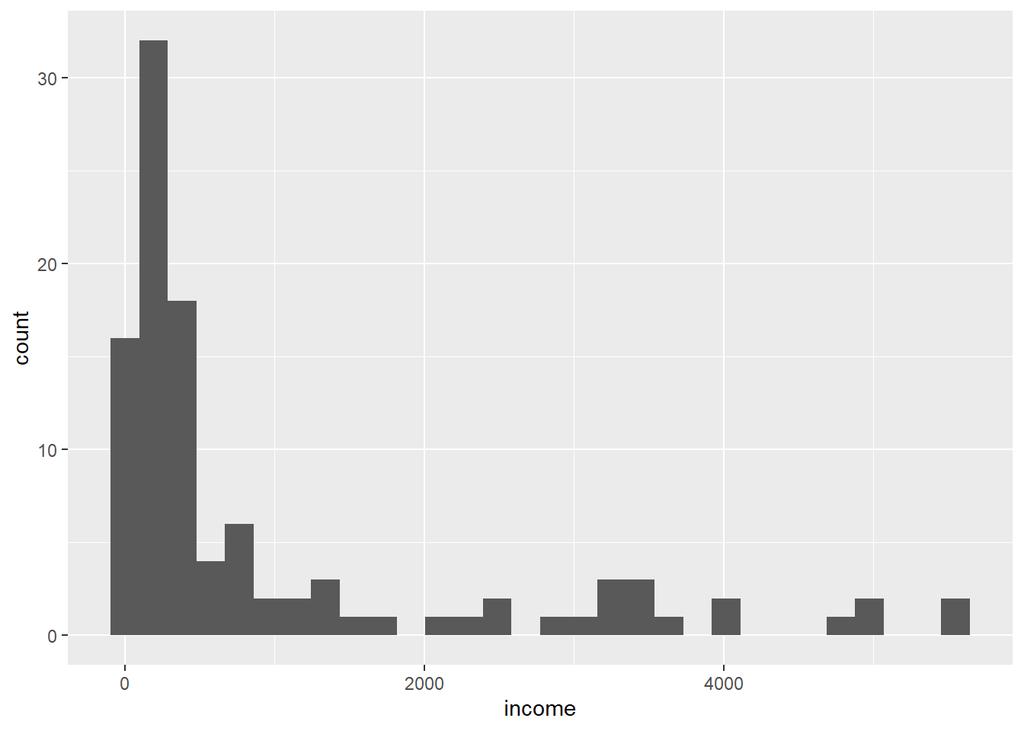

```r
ggplot(infmort, aes(x = income)) +
  geom_histogram()
```

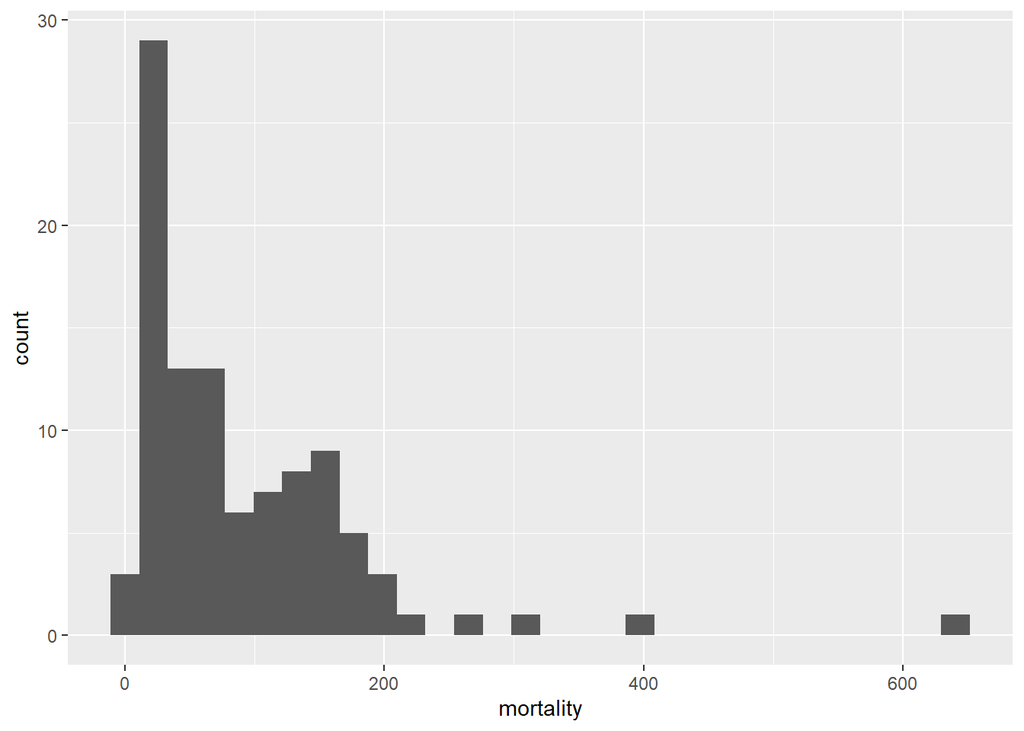

```r
ggplot(infmort, aes(x = mortality)) +
  geom_histogram()
```

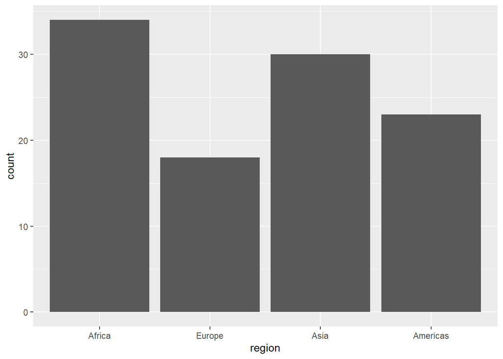

```r
ggplot(infmort, aes(x = region)) +
  geom_histogram(stat = "count")
```

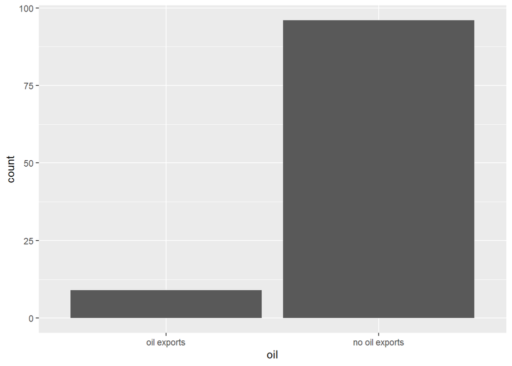

```r
ggplot(infmort, aes(x = oil)) +
  geom_histogram(stat = "count")
```

The full model shows income is not significant, but that oil and region might be.

```r
inf_fullmod <- lm(mortality ~ income + oil + region, data = infmort)
summary(inf_fullmod)
```

```
##
## Call:
## lm(formula = mortality ~ income + oil + region, data = infmort)
##
## Residuals:
##     Min      1Q  Median      3Q     Max
## -156.00  -32.20   -4.44   13.65  488.82
##
## Coefficients:
##                     Estimate Std. Error t value Pr(>|t|)
## (Intercept)        2.152e+02  2.974e+01   7.234 1.19e-10 ***
## income            -5.290e-03  7.404e-03  -0.714 0.476685
## oilno oil exports -7.834e+01  2.891e+01  -2.710 0.007992 **
## regionEurope      -1.015e+02  3.073e+01  -3.303 0.001351 **
## regionAsia        -4.589e+01  2.014e+01  -2.278 0.024977 *
## regionAmericas    -8.365e+01  2.180e+01  -3.837 0.000224 ***
## ---
## Signif. codes:  0 '***' 0.001 '**' 0.01 '*' 0.05 '.' 0.1 ' ' 1
##
## Residual standard error: 77.36 on 95 degrees of freedom
##   (4 observations deleted due to missingness)
## Multiple R-squared:  0.3105, Adjusted R-squared:  0.2742
## F-statistic: 8.556 on 5 and 95 DF,  p-value: 1.015e-06
```

Checking to see what each one does on it’s own, income is once again not significant.

```r
drop1(inf_fullmod, test = "F")
```

```
## Single term deletions
##
## Model:
## mortality ~ income + oil + region
##        Df Sum of Sq    RSS    AIC F value    Pr(>F)
## <none>              568491 884.20
## income  1      3055 571546 882.74  0.5105 0.4766846
## oil     1     43936 612427 889.72  7.3421 0.0079918 **
## region  3    109016 677507 895.92  6.0725 0.0007946 ***
## ---
## Signif. codes:  0 '***' 0.001 '**' 0.01 '*' 0.05 '.' 0.1 ' ' 1
```

```r
inf_partialmod <- lm(mortality ~ region + oil, data = infmort)
summary(inf_partialmod)
```

```
##
## Call:
## lm(formula = mortality ~ region + oil, data = infmort)
##
## Residuals:
##     Min      1Q  Median      3Q     Max
## -153.99  -31.55   -5.76   16.93  485.88
##
## Coefficients:
##                   Estimate Std. Error t value Pr(>|t|)
## (Intercept)         211.99      29.34   7.226 1.18e-10 ***
## regionEurope       -116.29      22.63  -5.138 1.46e-06 ***
## regionAsia          -47.87      19.90  -2.405   0.0181 *
## regionAmericas      -87.37      21.11  -4.138 7.51e-05 ***
## oilno oil exports   -76.45      28.72  -2.662   0.0091 **
## ---
## Signif. codes:  0 '***' 0.001 '**' 0.01 '*' 0.05 '.' 0.1 ' ' 1
##
## Residual standard error: 77.16 on 96 degrees of freedom
##   (4 observations deleted due to missingness)
## Multiple R-squared:  0.3068, Adjusted R-squared:  0.2779
## F-statistic: 10.62 on 4 and 96 DF,  p-value: 3.614e-07
```

Not a ton of improvement. Lets try region and oil as an interaction term.

```r
inf_partialmod_int <- lm(mortality ~ region:oil, data = infmort)
summary(inf_partialmod_int)
```

```
##
## Call:
## lm(formula = mortality ~ region:oil, data = infmort)
##
## Residuals:
##     Min      1Q  Median      3Q     Max
## -239.60  -29.63   -5.76   17.47  382.30
##
## Coefficients: (2 not defined because of singularities)
##                                  Estimate Std. Error t value Pr(>|t|)
## (Intercept)                         54.12      16.54   3.273  0.00149 **
## regionAfrica:oiloil exports         93.97      45.79   2.052  0.04291 *
## regionEurope:oiloil exports            NA         NA      NA       NA
## regionAsia:oiloil exports          213.58      45.79   4.664 1.02e-05 ***
## regionAmericas:oiloil exports       10.98      54.85   0.200  0.84183
## regionAfrica:oilno oil exports      87.60      21.21   4.130 7.85e-05 ***
## regionEurope:oilno oil exports     -34.87      24.03  -1.451  0.15004
## regionAsia:oilno oil exports        20.60      22.39   0.920  0.35982
## regionAmericas:oilno oil exports       NA         NA      NA       NA
## ---
## Signif. codes:  0 '***' 0.001 '**' 0.01 '*' 0.05 '.' 0.1 ' ' 1
##
## Residual standard error: 73.95 on 94 degrees of freedom
##   (4 observations deleted due to missingness)
## Multiple R-squared:  0.3765, Adjusted R-squared:  0.3367
## F-statistic: 9.458 on 6 and 94 DF,  p-value: 4.08e-08
```

This shows a slightly lower residual standard error, meaning our predictions are better, and the adjusted r-squared increased.

#Linear Model w/ R Chapter 6 ## Exercise 6.1

1. Using the sat dataset, fit a model with the total SAT score as the response and expend, salary, ratio and takers as predictors. Perform regression diagnostics on this model to answer the following questions. Display any plots that are relevant. Do not provide any plots about which you have nothing to say. Suggest possible improvements or corrections to the model where appropriate.

```r
?sat
```

```
## starting httpd help server ... done
```

```r
sat_model <- lm(total ~ expend + salary + ratio + takers, data = sat)
summary(sat_model)
```

```
##
## Call:
## lm(formula = total ~ expend + salary + ratio + takers, data = sat)
##
## Residuals:
##     Min      1Q  Median      3Q     Max
## -90.531 -20.855  -1.746  15.979  66.571
##
## Coefficients:
##              Estimate Std. Error t value Pr(>|t|)
## (Intercept) 1045.9715    52.8698  19.784  < 2e-16 ***
## expend         4.4626    10.5465   0.423    0.674
## salary         1.6379     2.3872   0.686    0.496
## ratio         -3.6242     3.2154  -1.127    0.266
## takers        -2.9045     0.2313 -12.559 2.61e-16 ***
## ---
## Signif. codes:  0 '***' 0.001 '**' 0.01 '*' 0.05 '.' 0.1 ' ' 1
##
## Residual standard error: 32.7 on 45 degrees of freedom
## Multiple R-squared:  0.8246, Adjusted R-squared:  0.809
## F-statistic: 52.88 on 4 and 45 DF,  p-value: < 2.2e-16
```

1. Check the constant variance assumption for the errors.

On the residuals vs fitted plot does appear a bit curved, such that the residuals are more positive on the lower and higher extremes of the x-values. This is slightly concerning so we will look at the square root of the absolute value of the errors, as this effectively doubles the resolution of the residuals to see more clearly.

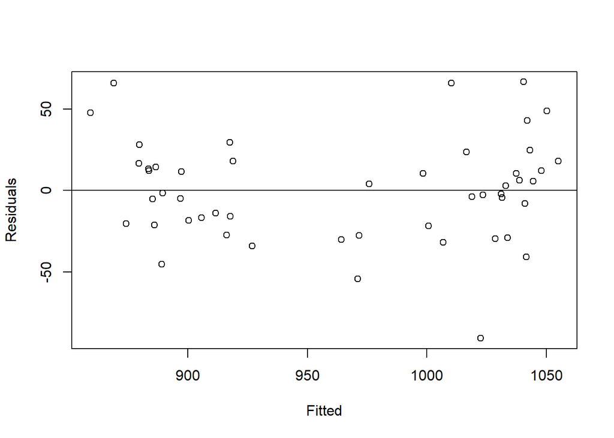

```r
plot(fitted(sat_model), residuals(sat_model), xlab = "Fitted", ylab = "Residuals")
abline(h=0)
```

This appears to have more constant variance and I don’t believe there is any reason to be concerned.

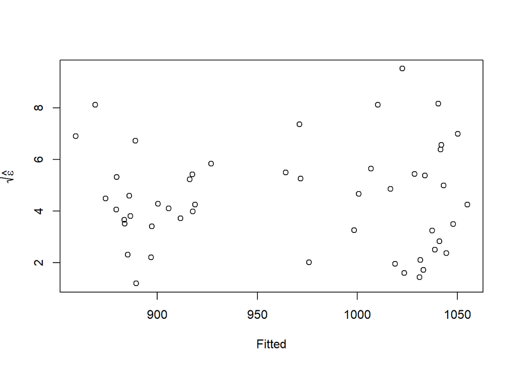

```r
plot(fitted(sat_model), sqrt(abs(residuals(sat_model))), xlab = "Fitted", ylab = expression(sqrt(hat(epsilon))))
```

2. Check the normality assumption.

There is some flaring toward the highest end of x-values, but otherwise the normality assumption is well-met.

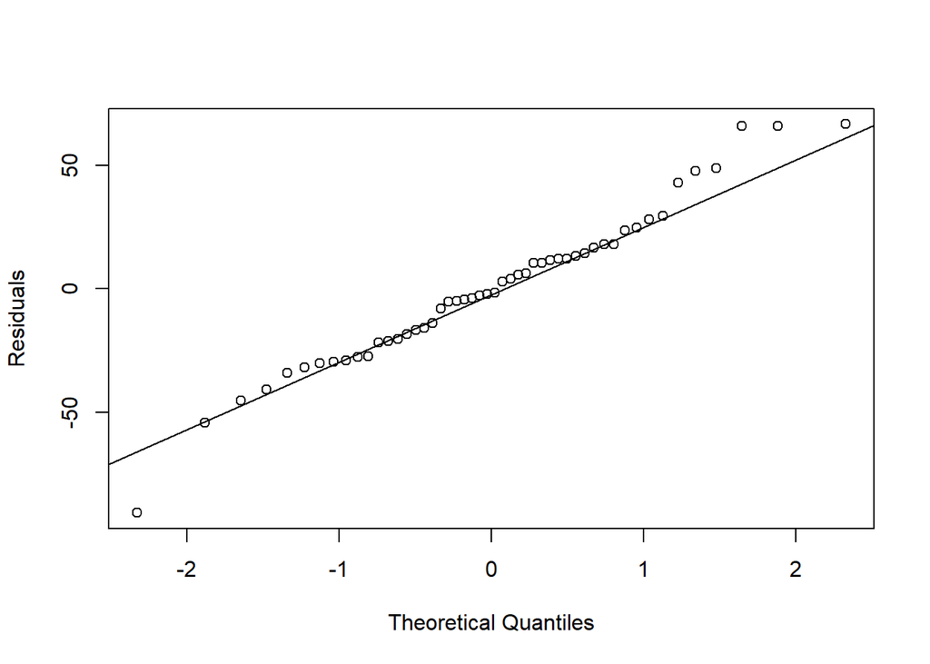

```r
qqnorm(residuals(sat_model), ylab = "Residuals", main = "")
qqline(residuals(sat_model))
```

3. Check for large leverage points.

```r
hatv <- hatvalues(sat_model)

head(sort(hatv, decreasing = TRUE), 10)
```

```
##        Utah  California Connecticut  New Jersey    New York      Alaska
##   0.2921128   0.2821179   0.2254519   0.2220978   0.1915752   0.1803061
##    Michigan    Virginia     Florida       Maine
##   0.1653683   0.1523058   0.1406859   0.1397360
```

```r
sum(hatv)
```

```
## [1] 5
```

We see Utah and California listed as being outliers, but do seem to fall in the trend of the rest of the data despite being very extreme x-values.

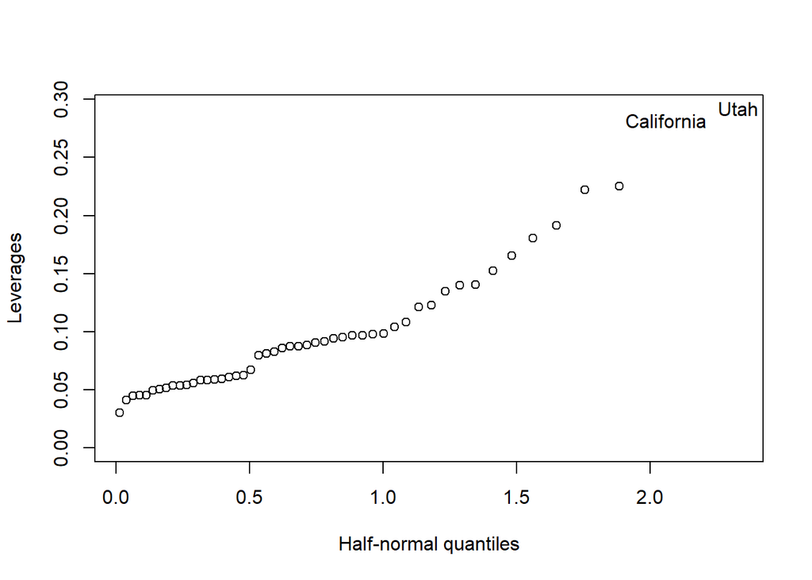

```r
states <- row.names(sat)
halfnorm(hatv, labs = states, ylab = "Leverages")
```

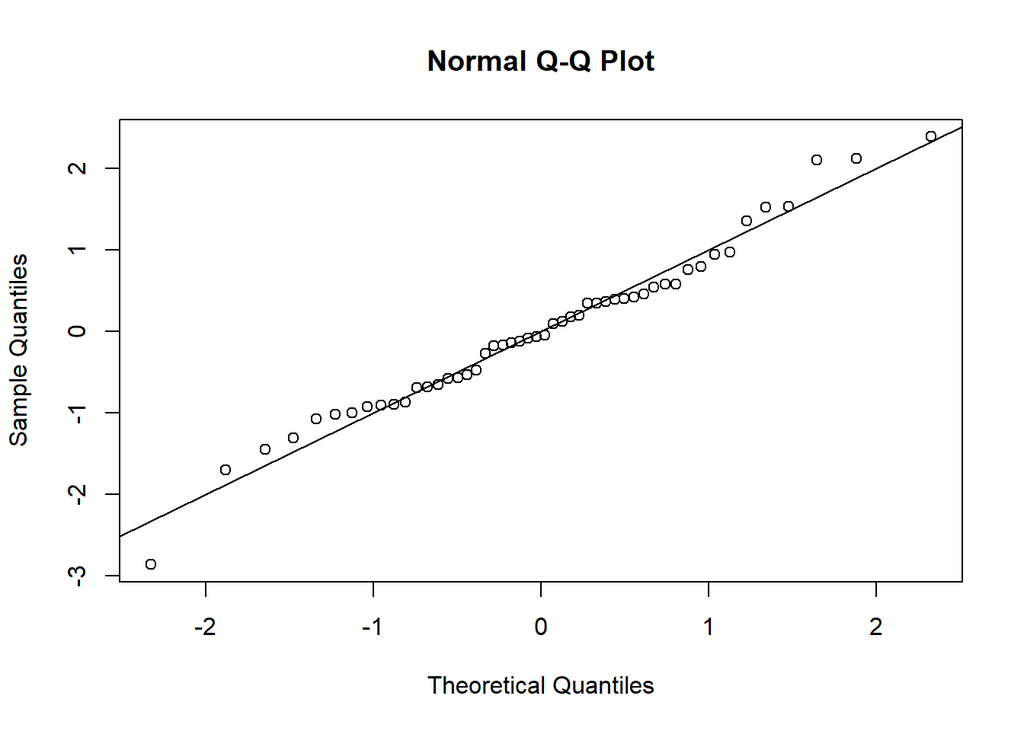

```r
qqnorm(rstandard(sat_model))
abline(0,1)
```

4. Check for outliers.

Using the Bonferroni correction we can compute if a value is a outlier. The general formula is qt(1-alpha/2, n-p).

```r
stud <- rstudent(sat_model)
stud[which.max(abs(stud))]
```

```
## West Virginia
##     -3.124428
```

```r
qt(p = 0.05/(50*2), df = 46)
```

```
## [1] -3.514957
```

5. Check for influential points.

An influential point is one whose removal from the dataset would cause a large change in in the fit. The Cook statistics are popular influence diagnostics because they reduce the information to a single value for each case. We see that Utah, West Virginia, and New Hampshire are the top 3 influential observations.

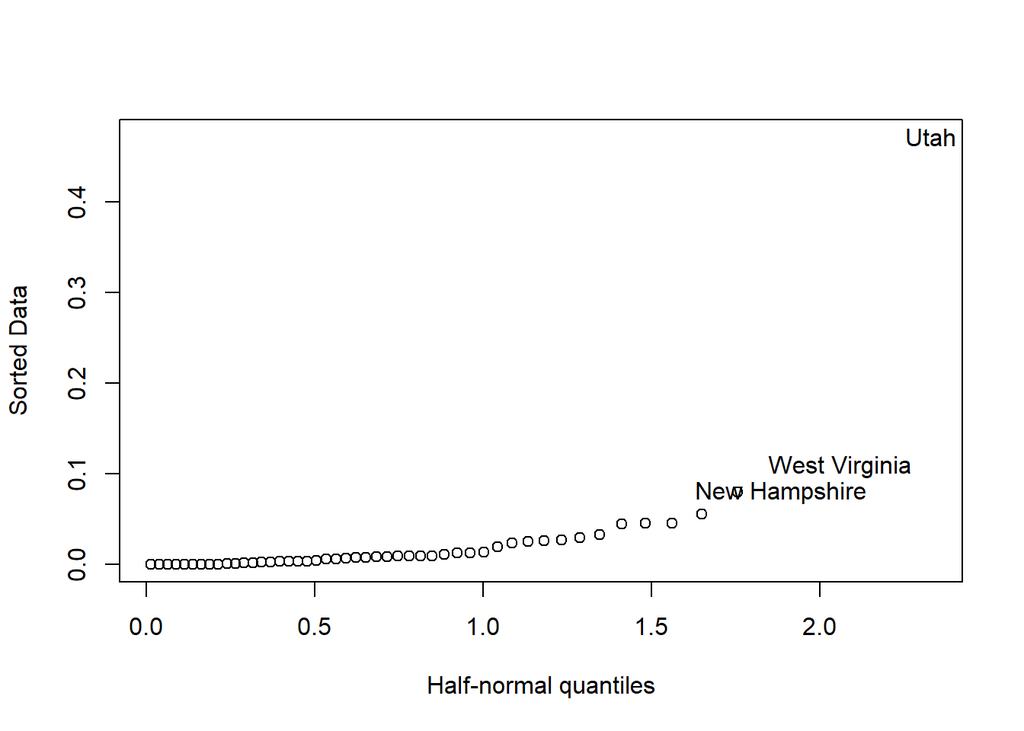

```r
cook <- cooks.distance(sat_model)
halfnorm(cook, 3, labs = states, y.lab = "Cook's distances")
```

To see the model with Utah removed. Compared to our original model, we see the coefficients for expend, salary, and ratio all changed by large magnitudes which is disconcerting that the estimates are so sensitive to just one state.

```r
sat_model_no_utah <- lm(total ~ expend + salary + ratio + takers, data = sat, subset = (cook < max(cook)))
summary(sat_model_no_utah)
```

```
##
## Call:
## lm(formula = total ~ expend + salary + ratio + takers, data = sat,
##     subset = (cook < max(cook)))
##
## Residuals:
##     Min      1Q  Median      3Q     Max
## -92.118 -18.402   1.808  14.890  67.669
##
## Coefficients:
##              Estimate Std. Error t value Pr(>|t|)
## (Intercept) 1093.8460    53.4226  20.475   <2e-16 ***
## expend        -0.9427    10.1922  -0.092    0.927
## salary         3.0964     2.3283   1.330    0.190
## ratio         -7.6391     3.4279  -2.229    0.031 *
## takers        -2.9308     0.2188 -13.397   <2e-16 ***
## ---
## Signif. codes:  0 '***' 0.001 '**' 0.01 '*' 0.05 '.' 0.1 ' ' 1
##
## Residual standard error: 30.9 on 44 degrees of freedom
## Multiple R-squared:  0.8396, Adjusted R-squared:  0.825
## F-statistic: 57.58 on 4 and 44 DF,  p-value: < 2.2e-16
```

```r
summary(sat_model)
```

```
##
## Call:
## lm(formula = total ~ expend + salary + ratio + takers, data = sat)
##
## Residuals:
##     Min      1Q  Median      3Q     Max
## -90.531 -20.855  -1.746  15.979  66.571
##
## Coefficients:
##              Estimate Std. Error t value Pr(>|t|)
## (Intercept) 1045.9715    52.8698  19.784  < 2e-16 ***
## expend         4.4626    10.5465   0.423    0.674
## salary         1.6379     2.3872   0.686    0.496
## ratio         -3.6242     3.2154  -1.127    0.266
## takers        -2.9045     0.2313 -12.559 2.61e-16 ***
## ---
## Signif. codes:  0 '***' 0.001 '**' 0.01 '*' 0.05 '.' 0.1 ' ' 1
##
## Residual standard error: 32.7 on 45 degrees of freedom
## Multiple R-squared:  0.8246, Adjusted R-squared:  0.809
## F-statistic: 52.88 on 4 and 45 DF,  p-value: < 2.2e-16
```

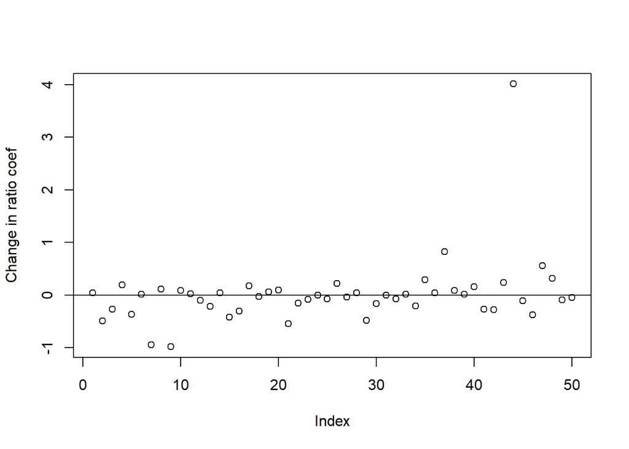

```r
plot(dfbeta(sat_model)[,4], ylab = "Change in ratio coef")
abline(h=0)
```

```r
### I can't get the identify() function to work to see outliers here
```

#Linear Models w/ R Chapter 9 ## Exercise 9.1 The aatemp data come from the U.S. Historical Climatology Network. They are the annual mean temperatures (in degrees F) in Ann Arbor, Michigan going back about 150 years.

```r
?aatemp
```

1. Is there a linear trend?

From this basic scatterplot it does appear there could be a positive linear trend. When adding the geom_smooth’s attempt at a linear model line there is a slight positive linear trend.

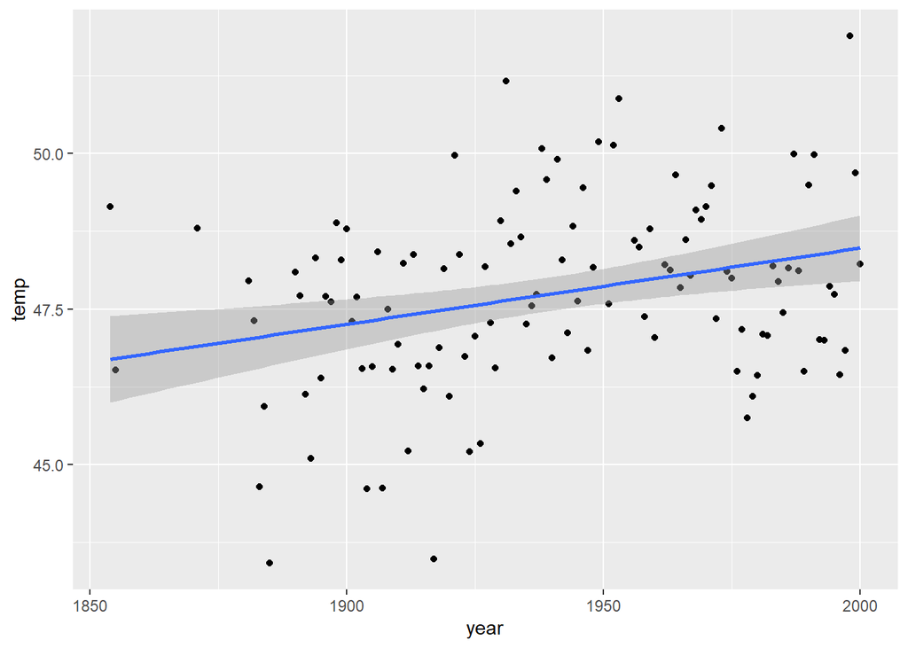

```r
ggplot(aatemp, aes(x = year, y = temp)) +
  geom_point() +
  geom_smooth(method = "lm")
```

2. Observations in successive years may be correlated. Fit a model that estimates this correlation. Does this change your opinion about the trend?  
   **Haven’t covered this concept in book yet**
3. Fit a polynomial model with degree 10 and use backward elimination to reduce the degree of the model. Plot your fitted model on top of the data. Use this model to predict the temperature in 2020.  
   **Haven’t covered this concept in book yet**
4. Suppose someone claims that the temperature was constant until 1930 and then began a linear trend. Fit a model corresponding to this claim. What does the fitted model say about this claim?  
   **Haven’t covered this concept in book yet**
5. Make a cubic spline fit with six basis functions evenly spaced on the range. Plot the fit in comparison to the previous fits. Does this model fit better than the straight-line model?  
   **Haven’t covered this concept in book yet**

## Exercise 9.3

Using the ozone data, fit a model with O3 as the response and temp, humidity and ibh as predictors. Use the Box–Cox method to determine the best transformation on the response.

```r
ozone_lm <- lm(O3 ~ temp + humidity + ibh, data = ozone)
```

```r
require(MASS)
```

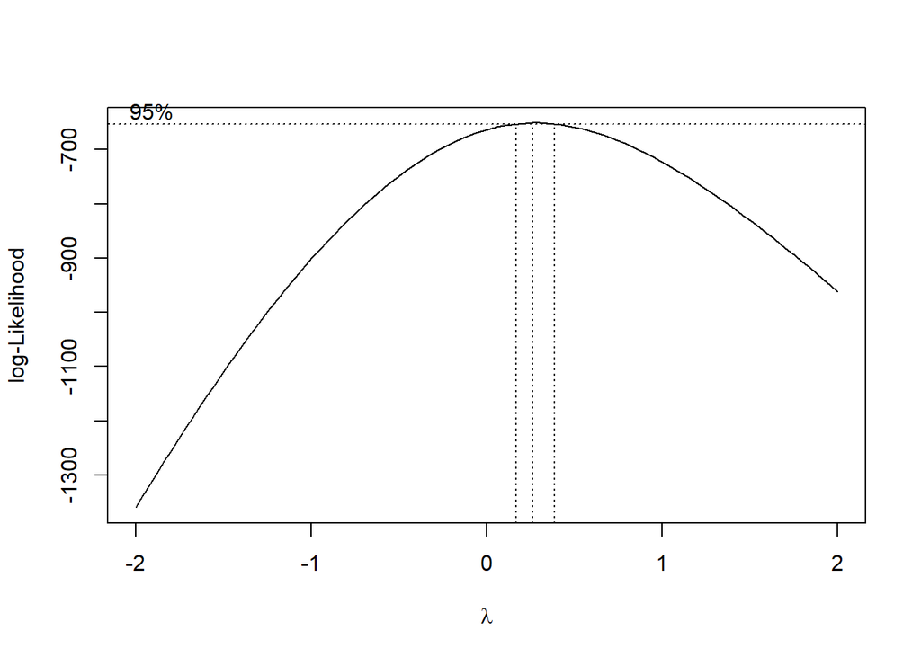

```r
boxcox(ozone_lm, plotit=T)
```

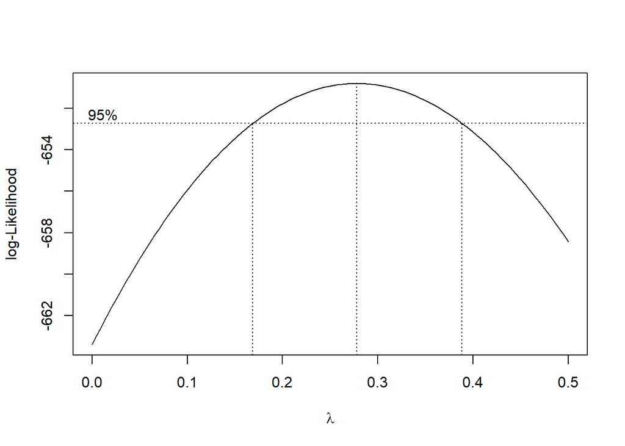

```r
# zoom in on the confidence interval
boxcox(ozone_lm, plotit=T,
       lambda = seq(0, 0.5, by = 0.1))
```

#Linear Models w/ R Chapter 13 ## Exercise 13.1 The dataset kanga contains data on the skulls of historical kangaroo specimens. Ignore the sex and species variables for the purposes of this question.

1. Report on the distribution of missing values within the data according to case and variable.  
   From the table below we can see that 101 of the cases have no missing values, 17 are missing only palate.width, 10 are missing mandible.length, and so on. Looking on the far right column for the totals, there are no cases missing more than 3 values. This is useful for seeing combinations/patterns of missing values.

If we sum the left column, except for the 101 complete cases, we can see that if we were to delete any incomplete cases we would lose 47 of 148 cases, 32% of the original data.

```r
# remove two categorical variables sex and species
kanga <- subset(kanga, select = -c(sex, species))


library(mice)
library(kableExtra)
```

```r
kable((md.pattern(kanga, plot = FALSE)), format = "html")
```

|  | nasal.width | lacrymal.width | orbital.width | crest.width | foramina.length | mandible.width | mandible.depth | ramus.height | basilar.length | palate.length | nasal.length | squamosal.depth | zygomatic.width | occipitonasal.length | .rostral.width | occipital.depth | mandible.length | palate.width |  |
| --- | --- | --- | --- | --- | --- | --- | --- | --- | --- | --- | --- | --- | --- | --- | --- | --- | --- | --- | --- |
| 101 | 1 | 1 | 1 | 1 | 1 | 1 | 1 | 1 | 1 | 1 | 1 | 1 | 1 | 1 | 1 | 1 | 1 | 1 | 0 |
| 17 | 1 | 1 | 1 | 1 | 1 | 1 | 1 | 1 | 1 | 1 | 1 | 1 | 1 | 1 | 1 | 1 | 1 | 0 | 1 |
| 10 | 1 | 1 | 1 | 1 | 1 | 1 | 1 | 1 | 1 | 1 | 1 | 1 | 1 | 1 | 1 | 1 | 0 | 1 | 1 |
| 1 | 1 | 1 | 1 | 1 | 1 | 1 | 1 | 1 | 1 | 1 | 1 | 1 | 1 | 1 | 1 | 1 | 0 | 0 | 2 |
| 8 | 1 | 1 | 1 | 1 | 1 | 1 | 1 | 1 | 1 | 1 | 1 | 1 | 1 | 1 | 1 | 0 | 1 | 1 | 1 |
| 1 | 1 | 1 | 1 | 1 | 1 | 1 | 1 | 1 | 1 | 1 | 1 | 1 | 1 | 1 | 1 | 0 | 1 | 0 | 2 |
| 1 | 1 | 1 | 1 | 1 | 1 | 1 | 1 | 1 | 1 | 1 | 1 | 1 | 1 | 1 | 1 | 0 | 0 | 0 | 3 |
| 2 | 1 | 1 | 1 | 1 | 1 | 1 | 1 | 1 | 1 | 1 | 1 | 1 | 1 | 1 | 0 | 1 | 1 | 1 | 1 |
| 1 | 1 | 1 | 1 | 1 | 1 | 1 | 1 | 1 | 1 | 1 | 1 | 1 | 1 | 1 | 0 | 1 | 1 | 0 | 2 |
| 1 | 1 | 1 | 1 | 1 | 1 | 1 | 1 | 1 | 1 | 1 | 1 | 1 | 1 | 0 | 1 | 1 | 1 | 0 | 2 |
| 1 | 1 | 1 | 1 | 1 | 1 | 1 | 1 | 1 | 1 | 1 | 1 | 1 | 0 | 1 | 1 | 1 | 1 | 0 | 2 |
| 1 | 1 | 1 | 1 | 1 | 1 | 1 | 1 | 1 | 1 | 1 | 1 | 0 | 1 | 1 | 1 | 1 | 1 | 1 | 1 |
| 1 | 1 | 1 | 1 | 1 | 1 | 1 | 1 | 1 | 1 | 1 | 0 | 1 | 1 | 0 | 1 | 0 | 1 | 1 | 3 |
| 1 | 1 | 1 | 1 | 1 | 1 | 1 | 1 | 1 | 1 | 0 | 1 | 1 | 1 | 1 | 1 | 1 | 1 | 1 | 1 |
| 1 | 1 | 1 | 1 | 1 | 1 | 1 | 1 | 1 | 0 | 1 | 1 | 1 | 1 | 1 | 1 | 1 | 1 | 0 | 2 |
|  | 0 | 0 | 0 | 0 | 0 | 0 | 0 | 0 | 1 | 1 | 1 | 1 | 1 | 2 | 3 | 11 | 12 | 24 | 57 |

I also like using the skim function. The complete rate only shows palate.width with a missing rate below 90% (at 84%) and 24 missing cases. The rest are not too concerning.

```r
library(skimr)
fix_windows_histograms() #otherwise histograms display as unicode
```

```
## This function will change your system locale. It may have other unintended effects.
```

```
## Continue? (Y/n)
```

```r
skim(kanga)
```

Data summary

| Name | kanga |
| --- | --- |
| Number of rows | 148 |
| Number of columns | 18 |
| _______________________ |  |
| Column type frequency: |  |
| numeric | 18 |
| ________________________ |  |
| Group variables | None |

**Variable type: numeric**

| skim_variable | n_missing | complete_rate | mean | sd | p0 | p25 | p50 | p75 | p100 | hist |
| --- | --- | --- | --- | --- | --- | --- | --- | --- | --- | --- |
| basilar.length | 1 | 0.99 | 1490.05 | 165.03 | 1030 | 1380.50 | 1486.0 | 1592.00 | 1893 | ▁▃▇▆▂ |
| occipitonasal.length | 2 | 0.99 | 1557.83 | 153.63 | 1121 | 1464.75 | 1566.5 | 1661.00 | 1945 | ▁▃▇▅▂ |
| palate.length | 1 | 0.99 | 1020.72 | 124.32 | 665 | 942.00 | 1016.0 | 1105.50 | 1315 | ▁▃▇▅▂ |
| palate.width | 24 | 0.84 | 256.91 | 32.16 | 172 | 233.75 | 256.0 | 282.00 | 332 | ▁▆▇▆▂ |
| nasal.length | 1 | 0.99 | 662.92 | 88.82 | 434 | 602.50 | 669.0 | 716.50 | 893 | ▁▅▇▃▂ |
| nasal.width | 0 | 1.00 | 232.78 | 29.57 | 141 | 214.75 | 233.5 | 251.50 | 308 | ▁▃▇▅▂ |
| squamosal.depth | 1 | 0.99 | 179.65 | 27.33 | 121 | 161.50 | 179.0 | 192.00 | 299 | ▂▇▂▁▁ |
| lacrymal.width | 0 | 1.00 | 441.37 | 42.68 | 303 | 411.00 | 440.0 | 470.25 | 547 | ▁▃▇▇▂ |
| zygomatic.width | 1 | 0.99 | 876.63 | 76.46 | 640 | 824.50 | 879.0 | 926.00 | 1090 | ▁▃▇▅▁ |
| orbital.width | 0 | 1.00 | 239.36 | 16.87 | 190 | 230.00 | 239.0 | 249.00 | 290 | ▁▃▇▂▁ |
| .rostral.width | 3 | 0.98 | 271.79 | 36.54 | 173 | 247.00 | 268.0 | 294.00 | 371 | ▁▆▇▅▁ |
| occipital.depth | 11 | 0.93 | 650.95 | 67.85 | 435 | 611.00 | 650.0 | 698.00 | 798 | ▁▂▇▆▃ |
| crest.width | 0 | 1.00 | 123.49 | 41.44 | 13 | 100.75 | 125.0 | 151.00 | 216 | ▁▅▇▇▂ |
| foramina.length | 0 | 1.00 | 94.51 | 14.55 | 60 | 84.75 | 94.5 | 104.00 | 137 | ▂▆▇▃▁ |
| mandible.length | 12 | 0.92 | 1247.10 | 145.16 | 856 | 1155.00 | 1241.5 | 1347.25 | 1568 | ▁▅▇▆▂ |
| mandible.width | 0 | 1.00 | 138.97 | 13.82 | 101 | 130.00 | 138.0 | 148.00 | 169 | ▁▂▇▅▃ |
| mandible.depth | 0 | 1.00 | 195.95 | 22.75 | 132 | 181.75 | 194.5 | 210.25 | 271 | ▁▅▇▃▁ |
| ramus.height | 0 | 1.00 | 698.79 | 77.54 | 473 | 648.75 | 700.0 | 751.50 | 880 | ▁▃▇▅▂ |

2. Determine a combination of variable and case deletions that retains the most information.

First we’ll delete any case with a missing value and see the correlation plot for any collinearity in variables.

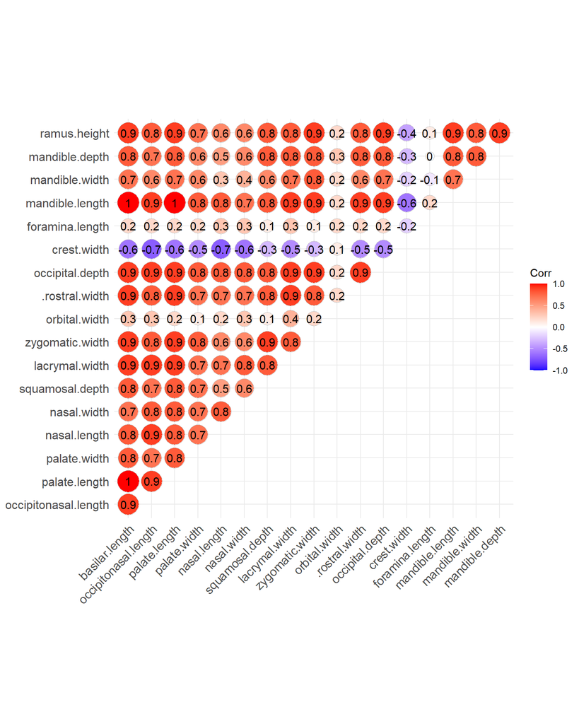

```r
# remove any row with an NA in any column
kanga_complete <- na.omit(kanga)

# correlation plot of complete cases from kanga
library(ggcorrplot)
corr <- round(cor(kanga_complete), 1)
ggcorrplot(corr, method = "circle", type = "upper", lab = TRUE, insig = "blank")
```

3. Compute the PCA, omitting all missing cases, where all the variables have been scaled to have SD 1. Report on the standard deviation of the principal components.  
   **Not covered in this class yet.**
4. Perform multiple imputation 25 times, applying PCA in the same manner to each of the imputed datasets. Combine the standard deviations of the principal components in the imputed datasets.  
   **Not covered in this class yet.**

## Exercise 13.2

2. The dataset galamiss contains the Galapagos data frequently featured as an example in this text as gala but with the original missing values left in.
1. Fit a linear model using gala with the number of species as the response and the five geographic predictors as in earlier examples.
2. Fit the same model to galamiss using the deletion strategy for missing values. Compare the fit to that in (a).
3. Use mean value single imputation on galamiss and again fit the model. Compare to previous fits.
4. Use a regression-based imputation using the other four geographic predictors to fill in the missing values in galamiss. Fit the same model and compare to previous fits.
5. Use multiple imputation to handle missing values and fit the same model again. Compare to previous fits.